```r
library(pacman)
```

```r
p_load("strmingr","ggplot2","ggExtra","lmerTest","tidyverse", "zoo","lubridate", "data.table", "ggthemes")
setwd("~/Historie projekt/historie project/LONSEA_DB/spring18/proportion_of_scandis")

da <- read.csv(list.files(pattern = "contract_"))
```

Subsetting scandinavians with section, director, chief, expert in fname (excluding sectretary of sections).

```r
top_scandi = da %>%
  filter(nationality %in% c("Dane", "Swedish","Norwegian"),str_detect(da$fname, "Section") | str_detect(da$fname, "Director") | str_detect(da$fname, "Chief") | str_detect(da$fname, "Expert"), fname != "Secretary of Section")
length(unique(droplevels(top_scandi$pname)))
```

```
## [1] 21
```

27 contracts from 21 scandinavians are found.

Contracts from treasury are removed (this amounts to 1).

First, the three economic sections are united under 1 Same for “Minorities” and “Admin. and Minotories”.

```r
oname_correct <- top_scandi %>%
  dplyr::mutate(oname = str_replace_all(oname, "Financial Section & Economic Intelligence Service","Economic and Financial Section"),
        oname = str_replace_all(oname, "Economic Relations Section","Economic and Financial Section"),
        oname = str_replace_all(oname, "Administrative and Minorities Section","Minorities Section"),
        oname = as.factor(oname)) %>%
  filter(oname != "Treasury") %>%
  droplevels



summary(oname_correct$oname)
```

```
##           Communications and Transit Section
##                                            1
## Department I (Department of General Affairs)
##                                            1
##                          Disarmament Section
##                                            2
##               Economic and Financial Section
##                                            6
##                               Health Section
##                                            1
##                          Information Section
##                                            2
##                                Legal Section
##                                            1
##                             Mandates Section
##                                            2
##                           Minorities Section
##                                            6
##                            Political Section
##                                            1
##   Social Questions and Opium Traffic Section
##                                            3
```

Distribution of scandinavians between sections

```r
employment_oname <- function(df, interval = "1 year"){

mdl_df <- df %>%
  select(pname, oname,begin_date, end_date) %>%
  mutate(begin_date = as.Date(begin_date),
         end_date = as.Date(end_date))



result <- setDT(mdl_df)[
  .(mseq = seq(as.Date("1919-01-01"), as.Date("1948-12-30"), by = interval)),
  on = .(begin_date <= mseq, end_date >= mseq), nomatch = 0L, allow.cartesian = TRUE][
    , dcast(unique(.SD), pname ~ end_date, toString, value.var = "oname")]
}
```

```r
library(plyr)
```

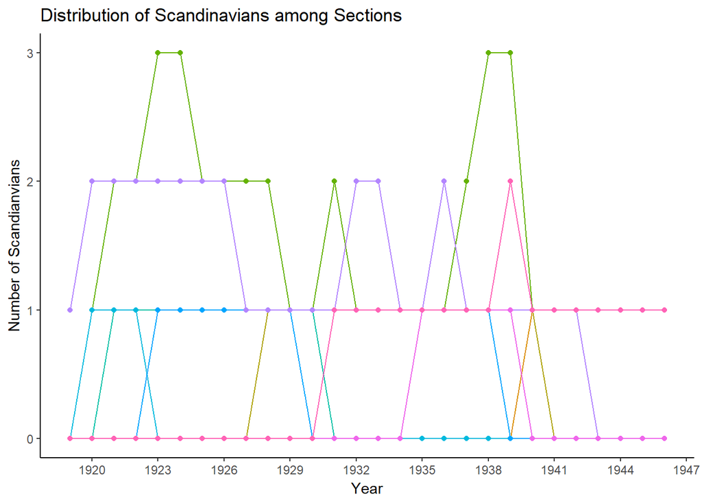

```r
scandi_res <- employment_oname(oname_correct)

scandi_res = droplevels(scandi_res)

scandi = scandi_res[,-1]


df = matrix(NA,nrow = nlevels(oname_correct$oname) * ncol(scandi),ncol =3)

count = 1
for (n in 1:ncol(scandi)){
  for (level in levels(oname_correct$oname)) {
    level_sum = sum(scandi[,n,with = F] == level)
    df[count,] = c(colnames(scandi)[n], level_sum, level)
    count = count + 1

  }
}

df = as.data.frame(df)
names(df) = c("year","count","section")

plot_df=df %>%
  mutate(count = as.numeric(as.character(count)),
         year = as.Date(year))

plot_df %>%
  ggplot(aes(year, count, color = section)) +
  geom_line() +
  theme_classic() +
  theme(legend.position="none")+
  geom_point() +
  scale_x_date(date_breaks = "3 year", date_labels = "%Y") +
  labs(x = "Year", y ="Number of Scandianvians", titles = "Distribution of Scandinavians among Sections")
```

Not the best graph.In the graph below is an explanation of the colors.

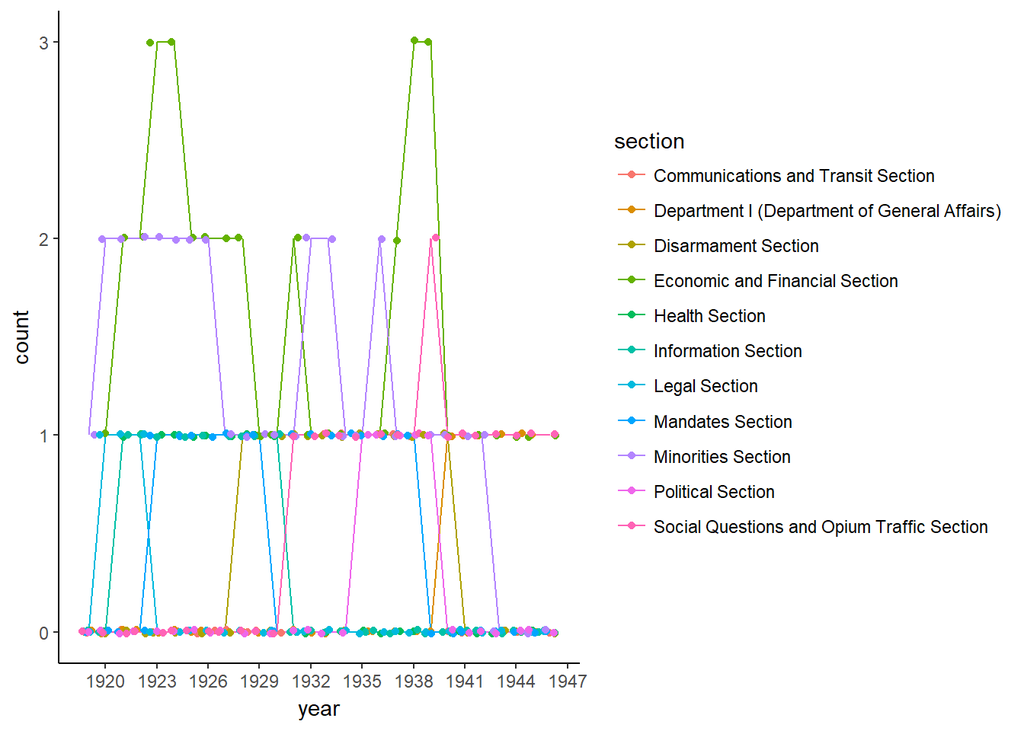

```r
plot_df %>%
  ggplot(aes(year, count, color = section)) +
  geom_line() +
  theme_classic() +
  theme(legend.position="right")+
  geom_jitter(height = 0.01) +
  scale_x_date(date_breaks = "3 year", date_labels = "%Y")
```

Calculating the proportion of sections that scandinavians make up

```r
top_people <- da %>%
  filter(str_detect(da$fname, "Section") | str_detect(da$fname, "Director") | str_detect(da$fname, "Chief") | str_detect(da$fname, "Expert"),
         fname != "Secretary of Section")

length(unique(droplevels(top_people$pname)))
```

```
## [1] 368
```

492 contracts from 368 different individuals are found

Uniting minorities and economics sections as well as removing treasury + library.

```r
correct_top <- top_people %>%
  dplyr::mutate(oname = str_replace_all(oname, "Financial Section & Economic Intelligence Service","Economic and Financial Section"),
        oname = str_replace_all(oname, "Economic Relations Section","Economic and Financial Section"),
        oname = str_replace_all(oname, "Administrative and Minorities Section","Minorities Section"),
        oname = as.factor(oname)) %>%
  filter(oname != "Treasury", oname != "Library") %>%
  droplevels

summary(correct_top$oname)
```

```
##                                                                                          Bombay Office
##                                                                                                      1
##                                                                                    Brussels Conference
##                                                                                                      1
##                                                                                    Central Opium Board
##                                                                                                      1
##                                                                                        Central Section
##                                                                                                      3
##                                                                     Communications and Transit Section
##                                                                                                     14
##                                                           Department I (Department of General Affairs)
##                                                                                                      3
##                                                                                          Department II
##                                                                                                      3
##                                                                                         Department III
##                                                                                                      1
##                                                                      Deputy Secretary-General's Office
##                                                                                                      4
##                                                                                    Disarmament Section
##                                                                                                     22
##                                                                              Distribution of Documents
##                                                                                                     16
##                                                      Eastern Bureau of the Health Section in Singapore
##                                                                                                      1
##                                                                         Economic and Financial Section
##                                                                                                     91
##                                                                                        Economic Bureau
##                                                                                                      1
##                                                                                         Health Section
##                                                                                                     62
##                                                                                    Information Section
##                                                                                                     61
##                                             Intellectual Cooperation and International Bureaux Section
##                                                                                                     11
##                                                                                Internal Administration
##                                                                                                      5
##                                                                                       Internal Control
##                                                                                                      4
##                                                                                         Labour Section
##                                                                                                      2
```

[output cut: 37 more lines]

```
##                                                                                                      1
##                                                                             Saar Plebiscite Commission
##                                                                                                      1
##                                                                                            Translation
##                                                                                                      1
##                                                                       Under-Secretary-General's Office
##                                                                                                      2
##                                      Under Secretaries-Generals' in charge of Political Section Office
##                                                                                                      3
## Under Secretary-Generals' in charge International Bureaux and Intellectual-Co-operation Section Office
##                                                                                                      2
##                                  Under Secretary-Generals' in charge of Internal Administration Office
##                                                                                                      3
##                                                                                            Unspecified
##                                                                                                      1
```

Only looking at section with scandinavians in them.

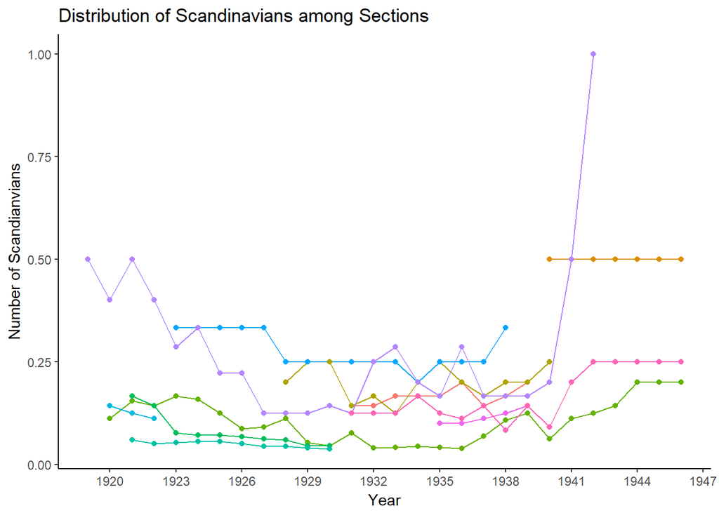

```r
library(plyr)
top_res <- employment_oname(correct_top)

scandi_res = droplevels(top_res)

top = top_res[,-1]


top_df = matrix(NA,nrow = nlevels(oname_correct$oname) * ncol(top),ncol =3)

count = 1
for (n in 1:ncol(top)){
  for (level in levels(oname_correct$oname)) {
    level_sum = sum(top[,n,with = F] == level)
    top_df[count,] = c(colnames(top)[n], level_sum, level)
    count = count + 1

  }
}

top_df = as.data.frame(top_df)
names(top_df) = c("year","count","section")

top_plot_df=top_df %>%
  mutate(count = as.numeric(as.character(count)),
         year = as.Date(year))

full_plot_df = merge(top_plot_df, plot_df, by = c("year","section"))
names(full_plot_df) = c("year","section","count_everyone","count_scandinavians")

full_plot_df = full_plot_df %>%
  mutate(proportion_scandinavians = count_scandinavians / count_everyone)

#full_plot_df$proportion_scandinavians[is.nan(full_plot_df$proportion_scandinavians)] <- 0

full_plot_df %>%
  filter(count_scandinavians > 0 ) %>%
  ggplot(aes(year, proportion_scandinavians, color = section)) +
  geom_line() +
  theme_classic() +
  theme(legend.position="none")+
  geom_point() +
  scale_x_date(date_breaks = "3 year", date_labels = "%Y") +
  labs(x = "Year", y ="Number of Scandianvians", titles = "Distribution of Scandinavians among Sections")
```

Data points with zero scandinavians are omitted to give a bit of clarity. Below is the same plot including color explanation.

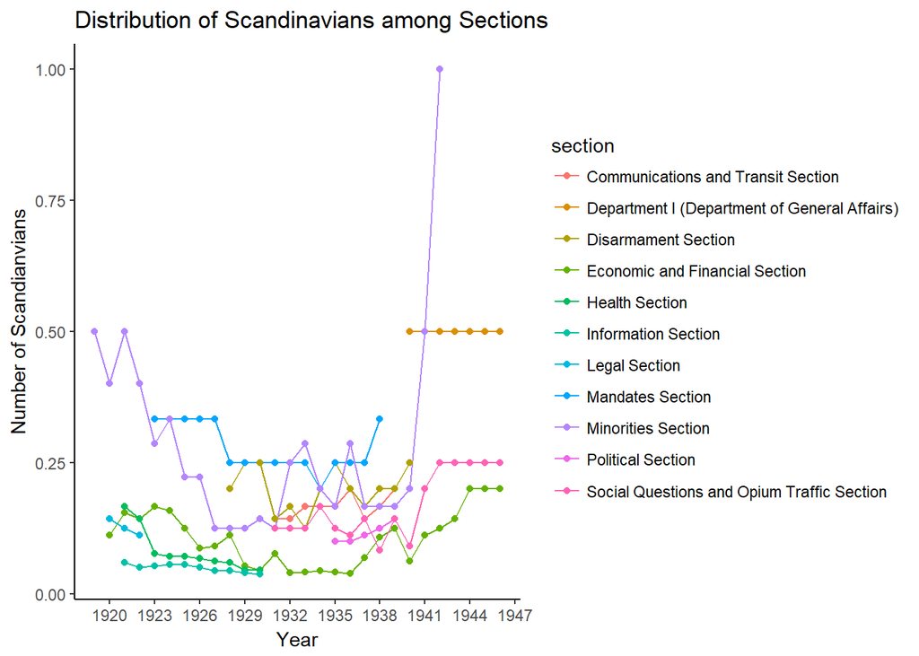

```r
full_plot_df %>%
  filter(count_scandinavians > 0 ) %>%
  ggplot(aes(year, proportion_scandinavians, color = section)) +
  geom_line() +
  theme_classic() +
  theme(legend.position="right")+
  geom_point() +
  scale_x_date(date_breaks = "3 year", date_labels = "%Y") +
  labs(x = "Year", y ="Number of Scandianvians", titles = "Distribution of Scandinavians among Sections")
```

Most sections only have 1 Scandinavian. Below is a plot showing the data points where more than one Scandinavians were present in a section.

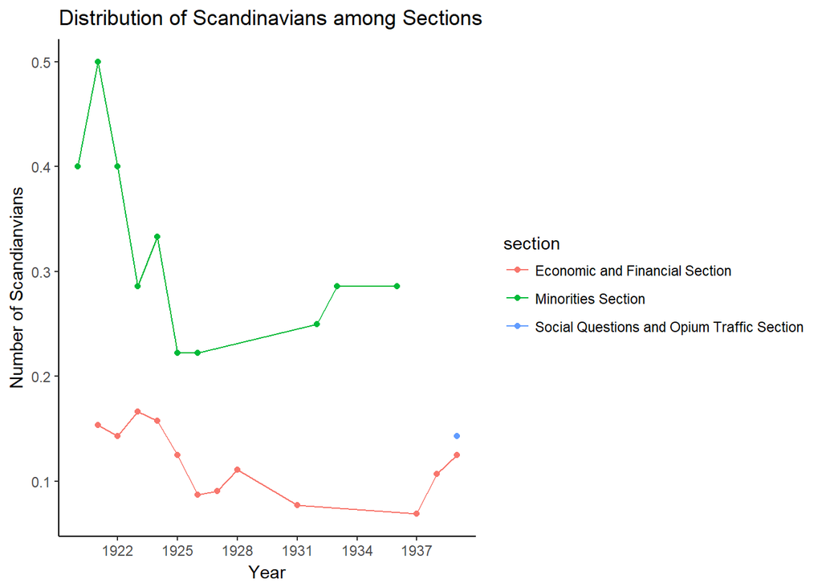

```r
full_plot_df %>%
  filter(count_scandinavians >1) %>%
  ggplot(aes(year, proportion_scandinavians, color = section)) +
  geom_line() +
  theme_classic() +
  theme(legend.position="right")+
  geom_point() +
  scale_x_date(date_breaks = "3 year", date_labels = "%Y") +
  labs(x = "Year", y ="Number of Scandianvians", titles = "Distribution of Scandinavians among Sections")
```

saving table with numbers

```r
#write.csv(full_plot_df, "scandi_comparison.csv")
```

Finally, A list of onames of people with section,director, chief, expert in the fname but who aren’t Scandinavian.

```r
correct_top = droplevels(correct_top)
oname_correct = droplevels(oname_correct)

levels(correct_top$oname)[!levels(correct_top$oname) %in% levels(oname_correct$oname)]
```

```
##  [1] "Bombay Office"
##  [2] "Brussels Conference"
##  [3] "Central Opium Board"
##  [4] "Central Section"
##  [5] "Department II"
##  [6] "Department III"
##  [7] "Deputy Secretary-General's Office"
##  [8] "Distribution of Documents"
##  [9] "Eastern Bureau of the Health Section in Singapore"
## [10] "Economic Bureau"
## [11] "Intellectual Cooperation and International Bureaux Section"
## [12] "Internal Administration"
## [13] "Internal Control"
## [14] "Labour Section"
## [15] "League of Nations"
```

[output cut: 20 more lines]